# 9.1(a): A single coin from a single mint

## Introduction

This is the first of two models in Section 9.1 of Kruschke. It has a lot of uncertainly about $\omega$, but a high degree of dependence of $\theta$ on $\omega$.

## Preliminaries

Load necessary packages:

```r
library(rstan)
library(shinystan)
library(bayesplot)
```

Set Stan to save compiled code.

```r
rstan_options(auto_write = TRUE)
```

Set Stan to use parallel processing where possible.

```r
options(mc.cores = parallel::detectCores())
```

## Data

```r
N <- 12
y <- c(rep(1, 9), rep(0, 3)) # 9 heads, 3 tails
stan_data <- list(N = N, y = y)
```

## Stan code

We use the `transformed data` block to define constants in our model: $A_{\omega}$ and $B_{\omega}$, the parameters for our beta hyperprior, and $K$, the *concentration* that reflects how tightly $\theta$ should stay to the mode $\omega$.

We use the `transformed parameters` block to define the parameters $a$ and $b$ of the beta prior for $\theta$. This is not strictly necessary, but it makes the `model` block much easier to read.

The `generated quantities` block uses a function that generates a Bernoulli distribution (either 1 or 0 for success or failure) given a probability of success $\theta$. In Stan, this block is run once every time the MCMC process accepts a target; for the value of $\theta$ that happens to be sampled in that round, the `for` loop generates $N$ “coin flips” given that value of $\theta$. The idea is that this becomes “fake data” generated from the posterior distrubution. It’s used in a posterior predictive check to make sure that the fake data generated from the posterior is consistent with the actual data we have. (Keep in mind, though, that it won’t be a perfect match; after all, the posterior is a compromise between the prior and the likelihood.)

```stan
data {
    int<lower = 0> N;
    int<lower = 0, upper = 1> y[N];
}
transformed data {
    real<lower = 0> A_omega;
    real<lower = 0> B_omega;
    real<lower = 0> K;

    A_omega = 2;
    B_omega = 2;
    K = 100;
}
parameters {
    real<lower = 0, upper = 1> omega;
    real<lower = 0, upper = 1> theta;
}
transformed parameters {
    real<lower = 0> a;
    real<lower = 0> b;

    a = omega * (K - 2) + 1;
    b = (1 - omega) * (K - 2) + 1;
}
model {
    omega ~ beta(A_omega, B_omega);
    theta ~ beta(a, b);
    y ~ bernoulli(theta);
}
generated quantities {
    int<lower = 0, upper = 1> y_rep[N];

    for (n in 1:N) {
        y_rep[n] = bernoulli_rng(theta);
    }
}
```

## Sampling from the model

```r
set.seed(11111)
fit_scsma <- sampling(scsma, data = stan_data, refresh = 0)
```

## Diagnosing the model

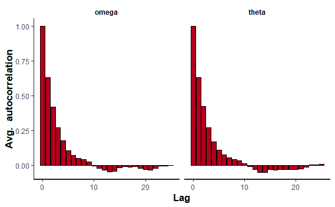

```r
plot(fit_scsma, plotfun = "ac", pars = c("omega", "theta"))
```

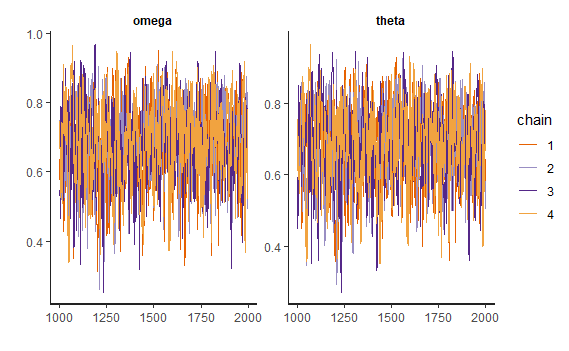

```r
plot(fit_scsma, plotfun = "trace",
     pars = c("omega", "theta"))
```

## Summarizing the model

```r
fit_scsma
```

```
Inference for Stan model: stan-367c4e2d3135.
4 chains, each with iter=2000; warmup=1000; thin=1;
post-warmup draws per chain=1000, total post-warmup draws=4000.

            mean se_mean    sd   2.5%    25%    50%   75% 97.5%
omega       0.68    0.00  0.12   0.43   0.61   0.69  0.77  0.88
theta       0.69    0.00  0.11   0.45   0.61   0.70  0.77  0.87
a          67.92    0.39 11.58  42.97  60.33  69.02 76.33 87.64
b          32.08    0.39 11.58  12.36  23.67  30.98 39.67 57.03
y_rep[1]    0.68    0.01  0.47   0.00   0.00   1.00  1.00  1.00
y_rep[2]    0.69    0.01  0.46   0.00   0.00   1.00  1.00  1.00
y_rep[3]    0.70    0.01  0.46   0.00   0.00   1.00  1.00  1.00
y_rep[4]    0.70    0.01  0.46   0.00   0.00   1.00  1.00  1.00
y_rep[5]    0.69    0.01  0.46   0.00   0.00   1.00  1.00  1.00
y_rep[6]    0.68    0.01  0.46   0.00   0.00   1.00  1.00  1.00
y_rep[7]    0.69    0.01  0.46   0.00   0.00   1.00  1.00  1.00
y_rep[8]    0.69    0.01  0.46   0.00   0.00   1.00  1.00  1.00
y_rep[9]    0.68    0.01  0.47   0.00   0.00   1.00  1.00  1.00
y_rep[10]   0.69    0.01  0.46   0.00   0.00   1.00  1.00  1.00
y_rep[11]   0.68    0.01  0.46   0.00   0.00   1.00  1.00  1.00
y_rep[12]   0.69    0.01  0.46   0.00   0.00   1.00  1.00  1.00
lp__      -10.35    0.03  1.02 -13.08 -10.77 -10.04 -9.61 -9.34
          n_eff Rhat
omega       865    1
theta       859    1
a           865    1
b           865    1
y_rep[1]   3510    1
y_rep[2]   2874    1
y_rep[3]   2997    1
y_rep[4]   3631    1
y_rep[5]   3715    1
y_rep[6]   3139    1
y_rep[7]   3111    1
y_rep[8]   3057    1
y_rep[9]   3589    1
y_rep[10]  3348    1
y_rep[11]  3461    1
y_rep[12]  3401    1
lp__       1146    1

Samples were drawn using NUTS(diag_e) at Sun May 26 13:56:03 2019.
For each parameter, n_eff is a crude measure of effective sample size,
and Rhat is the potential scale reduction factor on split chains (at
convergence, Rhat=1).
```

## Visualizing the model

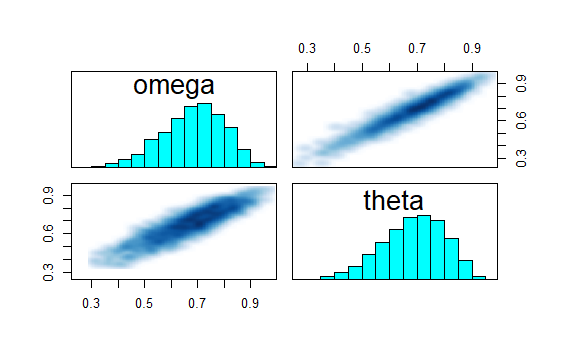

```r
pairs(fit_scsma, pars = c("omega", "theta"))
```

```
ci_level: 0.8 (80% intervals)
outer_level: 0.95 (95% intervals)
```

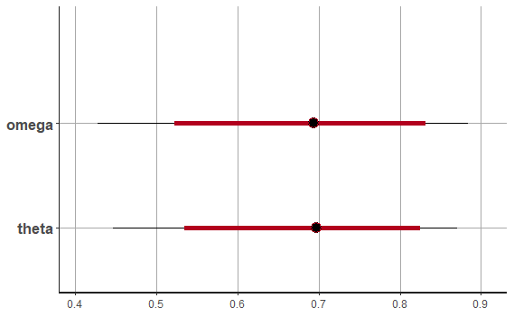

```r
plot(fit_scsma, pars = c("omega", "theta"))
```

## Examining the prior

Everything is the same here except the likelihood is commented out. (Also the `generated quantities` block is removed. In theory, that block could have been kept, and the fake data it would have generated is often called the “prior predictive distibution”.)

```stan
data {
    int<lower = 0> N;
    int<lower = 0, upper = 1> y[N];
}
transformed data {
    real<lower = 0> A_omega;
    real<lower = 0> B_omega;
    real<lower = 0> K;

    A_omega = 2;
    B_omega = 2;
    K = 100;
}
parameters {
    real<lower = 0, upper = 1> omega;
    real<lower = 0, upper = 1> theta;
}
transformed parameters {
    real<lower = 0> a;
    real<lower = 0> b;

    a = omega * (K - 2) + 1;
    b = (1 - omega) * (K - 2) + 1;
}
model {
    omega ~ beta(A_omega, B_omega);
    theta ~ beta(a, b);
//    y ~ bernoulli(theta);
}
```

```r
set.seed(11111)
fit_scsma_prior <- sampling(scsma_prior, data = stan_data, refresh = 0)
```

```r
fit_scsma_prior
```

```
Inference for Stan model: stan-367c1d2053a4.
4 chains, each with iter=2000; warmup=1000; thin=1;
post-warmup draws per chain=1000, total post-warmup draws=4000.

       mean se_mean    sd  2.5%   25%   50%   75% 97.5% n_eff Rhat
omega  0.49    0.01  0.22  0.09  0.31  0.48  0.66  0.90   759    1
theta  0.49    0.01  0.22  0.09  0.31  0.48  0.66  0.90   758    1
a     48.73    0.79 21.78 10.12 31.58 48.24 65.70 89.44   759    1
b     51.27    0.79 21.78 10.56 34.30 51.76 68.42 89.88   759    1
lp__  -3.27    0.04  1.16 -6.41 -3.75 -2.92 -2.43 -2.11   764    1

Samples were drawn using NUTS(diag_e) at Sun May 26 13:57:44 2019.
For each parameter, n_eff is a crude measure of effective sample size,
and Rhat is the potential scale reduction factor on split chains (at
convergence, Rhat=1).
```

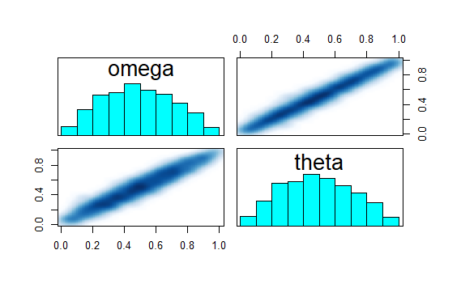

```r
pairs(fit_scsma_prior, pars = c("omega", "theta"))
```

```
ci_level: 0.8 (80% intervals)
outer_level: 0.95 (95% intervals)
```

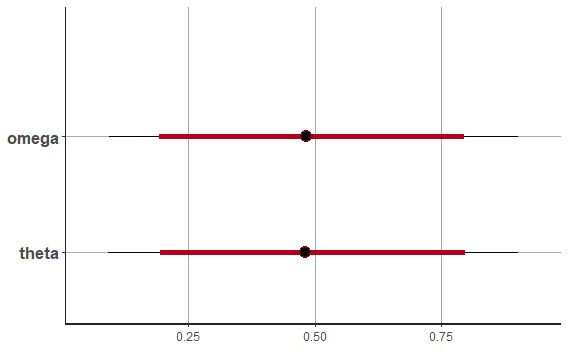

```r
plot(fit_scsma_prior, pars = c("omega", "theta"))
```

All of the above shows that the value of $\theta$ is stongly dependent on the value of $\omega$, the prior mode.

## Posterior predictive check

Extract predicted values:

```r
samples_scsma <- extract(fit_scsma)
y_rep <- samples_scsma$y_rep
```

Graph values of $y$ against summaries of $y_{rep}$:

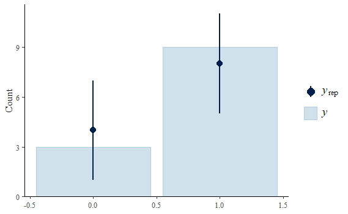

```r
ppc_bars(y, y_rep)
```

The bars represent the actual data (9 heads, 3 tails) whereas the dots with error bars represent the range of values in the simulated data from the posterior predictive distribution. Notice the “shrinkage”: the posterior predictions are pulled closer to 50% since that was the mode of the prior.

## ShinyStan

Run the following code from the Console:

```
launch_shinystan(fit_scsma)
```